# Biostat 203B Homework 3

Due Feb 22 @ 11:59PM

Author

Rebekah Patel and 605566820

Load necessary libraries (you can add more as needed).

```r
library(arrow)
library(gtsummary)
library(memuse)
library(pryr)
library(R.utils)
library(tidyverse)
library(data.table)
```

Display your machine memory.

```r
memuse::Sys.meminfo()
```

```
Totalram:    8.000 GiB
Freeram:   148.809 MiB
```

In this exercise, we use tidyverse (ggplot2, dplyr, etc) to explore the [MIMIC-IV](https://physionet.org/content/mimiciv/3.1/) data introduced in [homework 1](https://ucla-biostat-203b.github.io/2026winter/hw/hw1/hw1.html) and to build a cohort of ICU stays.

## Q1. Visualizing patient trajectory

Visualizing a patient’s encounters in a health care system is a common task in clinical data analysis. In this question, we will visualize a patient’s ADT (admission-discharge-transfer) history and ICU vitals in the MIMIC-IV data.

### Q1.1 ADT history

A patient’s ADT history records the time of admission, discharge, and transfer in the hospital. This figure shows the ADT history of the patient with `subject_id` 10001217 in the MIMIC-IV data. The x-axis is the calendar time, and the y-axis is the type of event (ADT, lab, procedure). The color of the line segment represents the care unit. The size of the line segment represents whether the care unit is an ICU/CCU. The crosses represent lab events, and the shape of the dots represents the type of procedure. The title of the figure shows the patient’s demographic information and the subtitle shows top 3 diagnoses.

[figure not shown]

Do a similar visualization for the patient with `subject_id` 10063848 using ggplot.

Hint: We need to pull information from data files `patients.csv.gz`, `admissions.csv.gz`, `transfers.csv.gz`, `labevents.csv.gz`, `procedures_icd.csv.gz`, `diagnoses_icd.csv.gz`, `d_icd_procedures.csv.gz`, and `d_icd_diagnoses.csv.gz`. For the big file `labevents.csv.gz`, use the Parquet format you generated in Homework 2. For reproducibility, make the Parquet folder `labevents_pq` available at the current working directory `hw3`, for example, by a symbolic link. Make your code reproducible.

```bash
#create a symbolic link to the Parquet folder for labevents
# ln -s ~/BIOSTAT203B/203b-hw/hw2/pq_files labevents_pq
```

```r
patient_id <- 10063848

patient_data <- fread("~/mimic/hosp/patients.csv.gz") |>
  filter(subject_id == patient_id) |>
  as_tibble()

admission_data <- fread("~/mimic/hosp/admissions.csv.gz") |>
  filter(subject_id == patient_id) |>
  as_tibble()

patient_title = str_c("Patient ", patient_id, ", ",
                      patient_data$gender, ", ",
                      patient_data$anchor_age, " years old, ",
                      str_to_title(admission_data$race[1]))
```

```r
transfer_data <- fread("~/mimic/hosp/transfers.csv.gz") |>
  filter(subject_id == patient_id) |>
  as_tibble()
```

```r
labevents <-
  open_dataset("labevents_pq", format = "parquet") |>
  to_duckdb() |>
  filter(subject_id == patient_id) |>
  collect()
```

```r
procedures_icd <-
  fread("~/mimic/hosp/procedures_icd.csv.gz") |>
  filter(subject_id == patient_id) |>
  left_join(
    fread("~/mimic/hosp/d_icd_procedures.csv.gz"),
    by = c("icd_code", "icd_version")) |>
  as_tibble()
```

```r
diagnoses_icd <-
  fread("~/mimic/hosp/diagnoses_icd.csv.gz") |>
  filter(subject_id == patient_id) |>
  left_join(
    fread("~/mimic/hosp/d_icd_diagnoses.csv.gz"),
    by = c("icd_code", "icd_version")
  ) |>
  as_tibble()

top3 <- diagnoses_icd |>
  group_by(icd_code, long_title) |>
  summarise(count = n()) |>
  arrange(desc(count)) |>
  ungroup() |>
  slice_head(n = 3) |>
  select(long_title)
str_top3 <- str_c(top3$long_title, collapse = "\n")
```

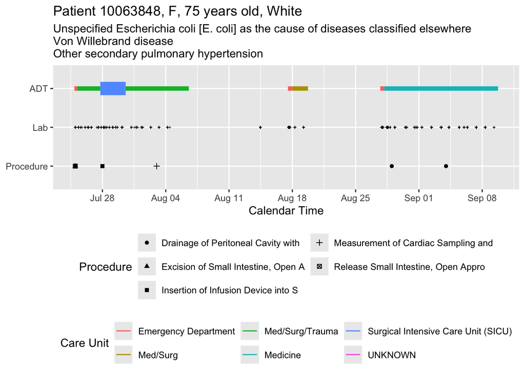

```r
# Create the ADT history plot using ggplot2
ggplot() +
    geom_segment(data = transfer_data,
                 aes(x = intime,
                     xend = outtime,
                     y = "ADT",
                     yend = "ADT",
                     color = careunit,
                     linewidth = str_detect(careunit, "ICU|CCU"))) +
  geom_point(data = procedures_icd,
             aes(x = chartdate,
                 y = "Procedure",
                 shape = str_sub(long_title, 1, 35))) +
  geom_point(data = labevents,
             aes(x = storetime, y = "Lab"),
             shape = "+") +
  labs(title = patient_title,
       subtitle = str_top3,
       x = "Calendar Time",
       shape = "Procedure",
       color = "Care Unit") +
  scale_x_datetime(date_breaks = "1 week",
               date_labels = "%b %d") +
  scale_y_discrete(limits = rev) +
  theme(legend.position = "bottom",
        legend.box = "vertical",
        legend.justification = "center",
        axis.title.y = element_blank()) +
    guides(linewidth = "none",
           shape = guide_legend(ncol = 2))
```

### Q1.2 ICU stays

ICU stays are a subset of ADT history. This figure shows the vitals of the patient `10001217` during ICU stays. The x-axis is the calendar time, and the y-axis is the value of the vital. The color of the line represents the type of vital. The facet grid shows the abbreviation of the vital and the stay ID.

[figure not shown]

Do a similar visualization for the patient `10063848`.

```r
icu_stays <-
  fread("~/mimic/icu/icustays.csv.gz") |>
  filter(subject_id == patient_id) |>
  as_tibble()
```

```bash
#ln -s ~/BIOSTAT203B/203b-hw/hw2/pq_chart chartevents_pq
```

```r
patient_vitals <-
  open_dataset("chartevents_pq", format = "parquet") |>
  to_duckdb() |>
  filter(subject_id == patient_id,
         itemid %in% c(220045, 220181,
                       220179, 223761, 220210)) |>
  collect() |>
  left_join(
    fread("~/mimic/icu/d_items.csv.gz"),
    by = "itemid"
  ) |>
  print(width=Inf)
```

```
# A tibble: 298 × 19
   subject_id  hadm_id  stay_id caregiver_id charttime
        <dbl>    <dbl>    <dbl>        <dbl> <dttm>
 1   10063848 21345067 31332266        15619 2177-07-27 21:00:00
 2   10063848 21345067 31332266        15619 2177-07-27 21:00:00
 3   10063848 21345067 31332266        15619 2177-07-27 21:02:00
 4   10063848 21345067 31332266        15619 2177-07-27 21:02:00
 5   10063848 21345067 31332266        15619 2177-07-27 22:00:00
 6   10063848 21345067 31332266        15619 2177-07-27 22:00:00
 7   10063848 21345067 31332266        15619 2177-07-27 22:02:00
 8   10063848 21345067 31332266        15619 2177-07-27 22:02:00
 9   10063848 21345067 31332266        15619 2177-07-27 23:00:00
10   10063848 21345067 31332266        15619 2177-07-27 23:00:00
   storetime           itemid value valuenum valueuom warning
   <dttm>               <dbl> <chr>    <dbl> <chr>      <dbl>
```

[output cut: 35 more lines]

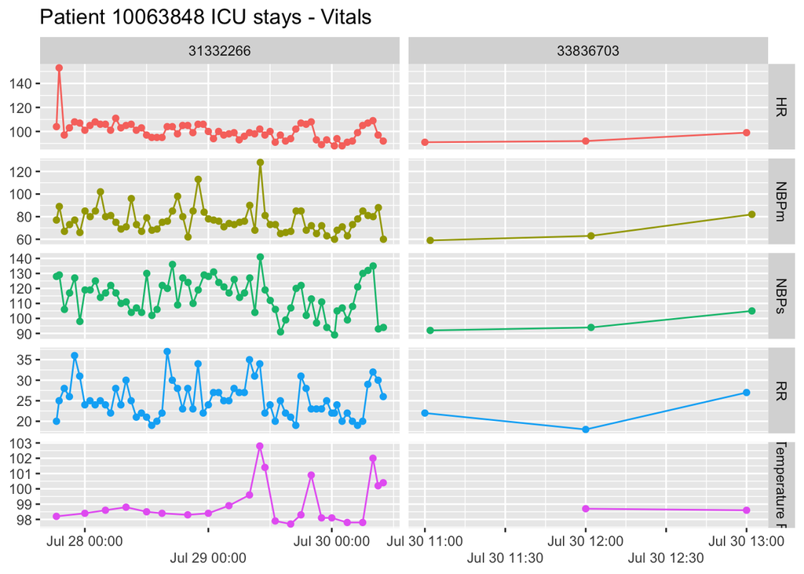

```r
# Create the ICU vitals plot using ggplot2
ggplot(patient_vitals,
       aes(x = charttime, y = valuenum,
           color = label)) +
  geom_line() +
  geom_point() +
  facet_grid(abbreviation ~ stay_id, scales = "free") +
  scale_x_datetime(date_labels = "%b %d %H:%M") +
  labs(
    title = str_c("Patient ", patient_id, " ICU stays - Vitals")
    ) +
  guides(color = "none") +
  theme(
    axis.title.y = element_blank(),
    axis.title.x = element_blank()
  ) +
  guides(x = guide_axis(n.dodge = 2))
```

## Q2. ICU stays

`icustays.csv.gz` (https://mimic.mit.edu/docs/iv/modules/icu/icustays/) contains data about Intensive Care Units (ICU) stays. The first 10 lines are

```bash
zcat < ~/mimic/icu/icustays.csv.gz | head
```

```
subject_id,hadm_id,stay_id,first_careunit,last_careunit,intime,outtime,los
10000032,29079034,39553978,Medical Intensive Care Unit (MICU),Medical Intensive Care Unit (MICU),2180-07-23 14:00:00,2180-07-23 23:50:47,0.4102662037037037
10000690,25860671,37081114,Medical Intensive Care Unit (MICU),Medical Intensive Care Unit (MICU),2150-11-02 19:37:00,2150-11-06 17:03:17,3.8932523148148146
10000980,26913865,39765666,Medical Intensive Care Unit (MICU),Medical Intensive Care Unit (MICU),2189-06-27 08:42:00,2189-06-27 20:38:27,0.4975347222222222
10001217,24597018,37067082,Surgical Intensive Care Unit (SICU),Surgical Intensive Care Unit (SICU),2157-11-20 19:18:02,2157-11-21 22:08:00,1.1180324074074075
10001217,27703517,34592300,Surgical Intensive Care Unit (SICU),Surgical Intensive Care Unit (SICU),2157-12-19 15:42:24,2157-12-20 14:27:41,0.948113425925926
10001725,25563031,31205490,Medical/Surgical Intensive Care Unit (MICU/SICU),Medical/Surgical Intensive Care Unit (MICU/SICU),2110-04-11 15:52:22,2110-04-12 23:59:56,1.338587962962963
10001843,26133978,39698942,Medical/Surgical Intensive Care Unit (MICU/SICU),Medical/Surgical Intensive Care Unit (MICU/SICU),2134-12-05 18:50:03,2134-12-06 14:38:26,0.8252662037037037
10001884,26184834,37510196,Medical Intensive Care Unit (MICU),Medical Intensive Care Unit (MICU),2131-01-11 04:20:05,2131-01-20 08:27:30,9.17181712962963
10002013,23581541,39060235,Cardiac Vascular Intensive Care Unit (CVICU),Cardiac Vascular Intensive Care Unit (CVICU),2160-05-18 10:00:53,2160-05-19 17:33:33,1.314351851851852
```

### Q2.1 Ingestion

Import `icustays.csv.gz` as a tibble `icustays_tble`.

```r
icustays_tble <-
  fread("~/mimic/icu/icustays.csv.gz") |>
  as_tibble() |>
  print(width=Inf)
```

```
# A tibble: 94,458 × 8
   subject_id  hadm_id  stay_id first_careunit
        <int>    <int>    <int> <chr>
 1   10000032 29079034 39553978 Medical Intensive Care Unit (MICU)
 2   10000690 25860671 37081114 Medical Intensive Care Unit (MICU)
 3   10000980 26913865 39765666 Medical Intensive Care Unit (MICU)
 4   10001217 24597018 37067082 Surgical Intensive Care Unit (SICU)
 5   10001217 27703517 34592300 Surgical Intensive Care Unit (SICU)
 6   10001725 25563031 31205490 Medical/Surgical Intensive Care Unit (MICU/SICU)
 7   10001843 26133978 39698942 Medical/Surgical Intensive Care Unit (MICU/SICU)
 8   10001884 26184834 37510196 Medical Intensive Care Unit (MICU)
 9   10002013 23581541 39060235 Cardiac Vascular Intensive Care Unit (CVICU)
10   10002114 27793700 34672098 Coronary Care Unit (CCU)
   last_careunit                                    intime
   <chr>                                            <dttm>
```

[output cut: 23 more lines]

### Q2.2 Summary and visualization

How many unique `subject_id`? Can a `subject_id` have multiple ICU stays? Summarize the number of ICU stays per `subject_id` by graphs.

```r
icustays_tble |>
  summarise(num_subjects = n_distinct(subject_id))
```

```
# A tibble: 1 × 1
  num_subjects
         <int>
1        65366
```

```
# A tibble: 65,366 × 2
   subject_id num_stays
        <int>     <int>
 1   10000032         1
 2   10000690         1
 3   10000980         1
 4   10001217         2
 5   10001725         1
 6   10001843         1
 7   10001884         1
 8   10002013         1
 9   10002114         1
10   10002155         3
# ℹ 65,356 more rows
```

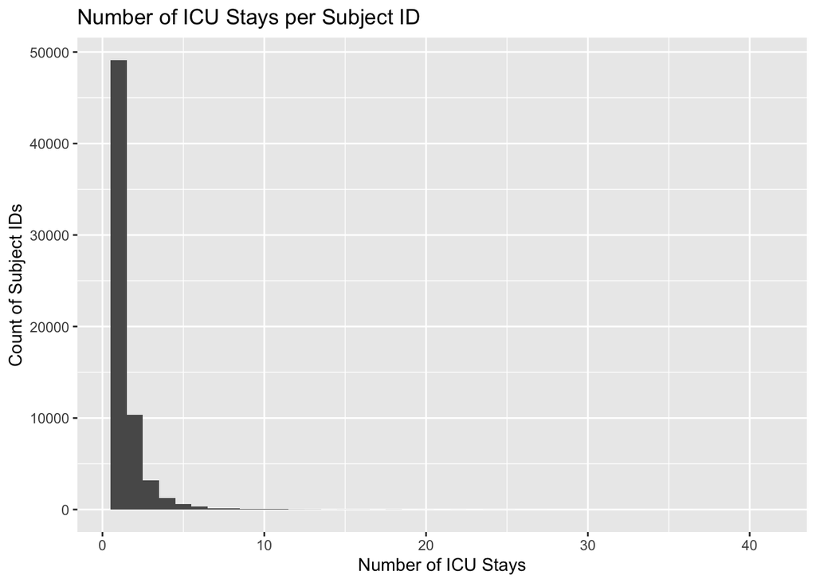

```r
icustays_tble |>
  group_by(subject_id) |>
  summarise(num_stays = n()) |>
  ungroup() |>
  print(width = Inf) |>
  ggplot(aes(x = num_stays)) +
  geom_histogram(binwidth = 1) +
  labs(title = "Number of ICU Stays per Subject ID",
       x = "Number of ICU Stays",
       y = "Count of Subject IDs")
```

**Solution:** There are 65,366 patients admitted into the hospital. Majority of patients only have one to two stays, but there are patients who have more than 10 stays.

## Q3. `admissions` data

Information of the patients admitted into hospital is available in `admissions.csv.gz`. See https://mimic.mit.edu/docs/iv/modules/hosp/admissions/ for details of each field in this file. The first 10 lines are

```bash
zcat < ~/mimic/hosp/admissions.csv.gz | head
```

```
subject_id,hadm_id,admittime,dischtime,deathtime,admission_type,admit_provider_id,admission_location,discharge_location,insurance,language,marital_status,race,edregtime,edouttime,hospital_expire_flag
10000032,22595853,2180-05-06 22:23:00,2180-05-07 17:15:00,,URGENT,P49AFC,TRANSFER FROM HOSPITAL,HOME,Medicaid,English,WIDOWED,WHITE,2180-05-06 19:17:00,2180-05-06 23:30:00,0
10000032,22841357,2180-06-26 18:27:00,2180-06-27 18:49:00,,EW EMER.,P784FA,EMERGENCY ROOM,HOME,Medicaid,English,WIDOWED,WHITE,2180-06-26 15:54:00,2180-06-26 21:31:00,0
10000032,25742920,2180-08-05 23:44:00,2180-08-07 17:50:00,,EW EMER.,P19UTS,EMERGENCY ROOM,HOSPICE,Medicaid,English,WIDOWED,WHITE,2180-08-05 20:58:00,2180-08-06 01:44:00,0
10000032,29079034,2180-07-23 12:35:00,2180-07-25 17:55:00,,EW EMER.,P06OTX,EMERGENCY ROOM,HOME,Medicaid,English,WIDOWED,WHITE,2180-07-23 05:54:00,2180-07-23 14:00:00,0
10000068,25022803,2160-03-03 23:16:00,2160-03-04 06:26:00,,EU OBSERVATION,P39NWO,EMERGENCY ROOM,,,English,SINGLE,WHITE,2160-03-03 21:55:00,2160-03-04 06:26:00,0
10000084,23052089,2160-11-21 01:56:00,2160-11-25 14:52:00,,EW EMER.,P42H7G,WALK-IN/SELF REFERRAL,HOME HEALTH CARE,Medicare,English,MARRIED,WHITE,2160-11-20 20:36:00,2160-11-21 03:20:00,0
10000084,29888819,2160-12-28 05:11:00,2160-12-28 16:07:00,,EU OBSERVATION,P35NE4,PHYSICIAN REFERRAL,,Medicare,English,MARRIED,WHITE,2160-12-27 18:32:00,2160-12-28 16:07:00,0
10000108,27250926,2163-09-27 23:17:00,2163-09-28 09:04:00,,EU OBSERVATION,P40JML,EMERGENCY ROOM,,,English,SINGLE,WHITE,2163-09-27 16:18:00,2163-09-28 09:04:00,0
10000117,22927623,2181-11-15 02:05:00,2181-11-15 14:52:00,,EU OBSERVATION,P47EY8,EMERGENCY ROOM,,Medicaid,English,DIVORCED,WHITE,2181-11-14 21:51:00,2181-11-15 09:57:00,0
```

### Q3.1 Ingestion

Import `admissions.csv.gz` as a tibble `admissions_tble`.

**Solution:**

```r
admissions_tble <-
  fread("~/mimic/hosp/admissions.csv.gz") |>
  as_tibble() |>
  print(n=10, wide=Inf)
```

```
# A tibble: 546,028 × 16
   subject_id  hadm_id admittime           dischtime
        <int>    <int> <dttm>              <dttm>
 1   10000032 22595853 2180-05-06 22:23:00 2180-05-07 17:15:00
 2   10000032 22841357 2180-06-26 18:27:00 2180-06-27 18:49:00
 3   10000032 25742920 2180-08-05 23:44:00 2180-08-07 17:50:00
 4   10000032 29079034 2180-07-23 12:35:00 2180-07-25 17:55:00
 5   10000068 25022803 2160-03-03 23:16:00 2160-03-04 06:26:00
 6   10000084 23052089 2160-11-21 01:56:00 2160-11-25 14:52:00
 7   10000084 29888819 2160-12-28 05:11:00 2160-12-28 16:07:00
 8   10000108 27250926 2163-09-27 23:17:00 2163-09-28 09:04:00
 9   10000117 22927623 2181-11-15 02:05:00 2181-11-15 14:52:00
10   10000117 27988844 2183-09-18 18:10:00 2183-09-21 16:30:00
# ℹ 546,018 more rows
# ℹ 12 more variables: deathtime <dttm>, admission_type <chr>,
#   admit_provider_id <chr>, admission_location <chr>,
#   discharge_location <chr>, insurance <chr>, language <chr>,
#   marital_status <chr>, race <chr>, edregtime <dttm>, edouttime <dttm>,
#   hospital_expire_flag <int>
```

### Q3.2 Summary and visualization

Summarize the following information by graphics and explain any patterns you see.

- number of admissions per patient
- admission hour (anything unusual?)
- admission minute (anything unusual?)
- length of hospital stay (from admission to discharge) (anything unusual?)

According to the [MIMIC-IV documentation](https://mimic.mit.edu/docs/iv/about/concepts/#date-shifting),

> All dates in the database have been shifted to protect patient confidentiality. Dates will be internally consistent for the same patient, but randomly distributed in the future. Dates of birth which occur in the present time are not true dates of birth. Furthermore, dates of birth which occur before the year 1900 occur if the patient is older than 89. In these cases, the patient’s age at their first admission has been fixed to 300.

**Solution:** The graph of the number of admissions per patient.

```
# A tibble: 97 × 2
   num_admissions      n
            <int>  <int>
 1              1 123289
 2              2  44123
 3              3  20108
 4              4  11172
 5              5   6629
 6              6   4312
 7              7   2964
 8              8   2187
 9              9   1651
10             10   1266
# ℹ 87 more rows
```

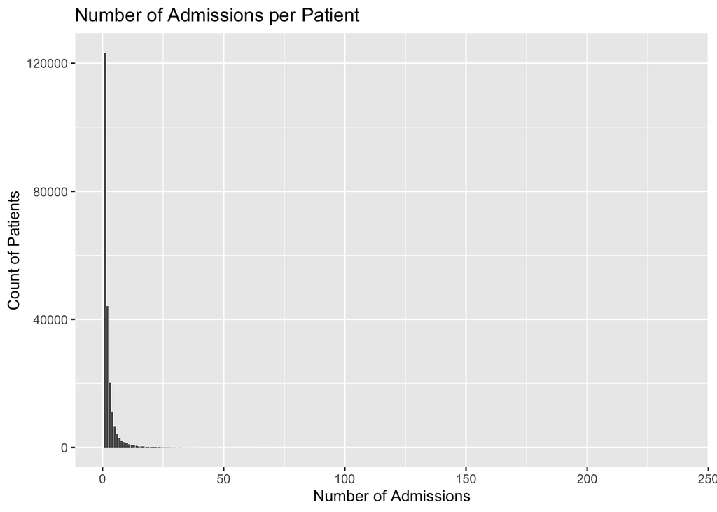

```r
admissions_tble |>
  group_by(subject_id) |>
  summarise(num_admissions = n()) |>
  ungroup() |>
  count(num_admissions) |>
  print(width = Inf) |>

  ggplot(aes(x = num_admissions, y = n)) +
  geom_col(binwidth = 1) +
  labs(title = "Number of Admissions per Patient",
       x = "Number of Admissions",
       y = "Count of Patients")
```

Majority of patients had only a few admissions, with 1 admission being the most common. There are some patients with over 12 admissions, but they are relatively rare. This is likely because most patients only require one or a few hospitalizations in their lifetime, while a smaller subset of patients may have chronic conditions or complex medical needs that require multiple hospitalizations.

The graph of the admission hour.

```
# A tibble: 24 × 2
   admission_hour     n
            <int> <int>
 1              0 40602
 2              1 20793
 3              2 17305
 4              3 13560
 5              4 13344
 6              5 11870
 7              6 11797
 8              7 23941
 9              8 12729
10              9  9951
# ℹ 14 more rows
```

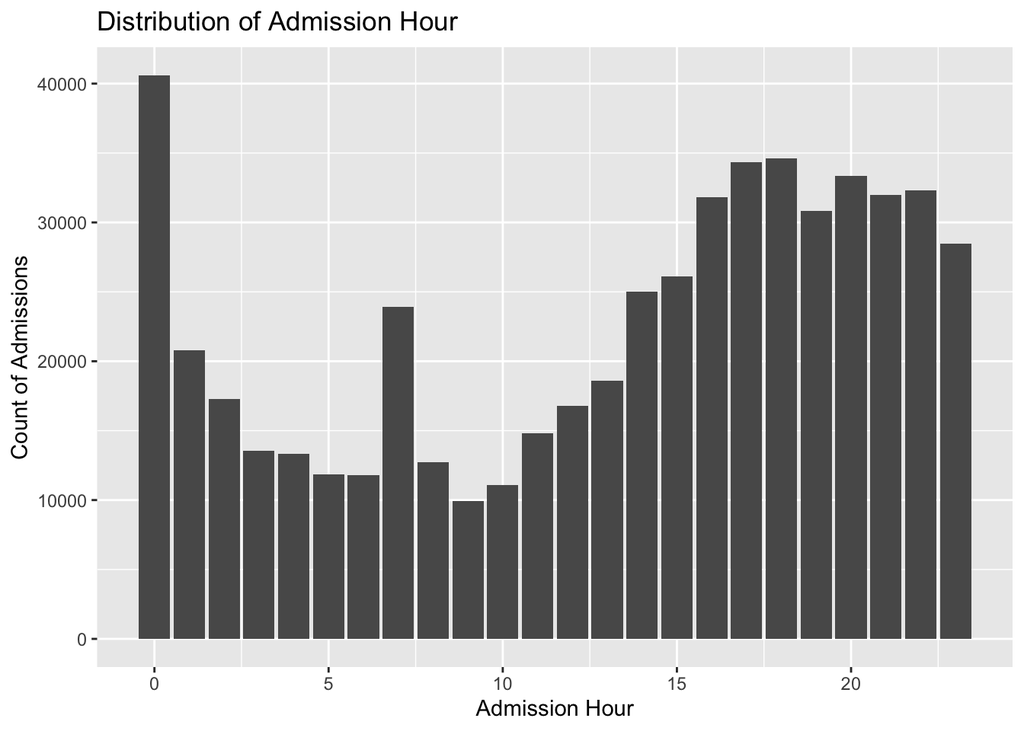

```r
admissions_tble |>
  mutate(admission_hour = hour(admittime)) |>
  count(admission_hour) |>
  print(width = Inf) |>
  ggplot(aes(x = admission_hour, y = n)) +
  geom_col(binwidth = 1) +
  labs(title = "Distribution of Admission Hour",
       x = "Admission Hour",
       y = "Count of Admissions")
```

After 12am, there is a dip in admissions, except for a spike at 7am, and then an increase after 10am. Admissions continue to rise until 4pm and stay at high levels until 12am. The spike at 7am may be due to the fact that many patients are admitted to the hospital in the morning after being evaluated in the emergency department or after being transferred from another hospital. The increase after 10am may be due to the fact that many elective surgeries and procedures are scheduled in the morning, leading to a higher number of admissions during this time. Also more accidents or emergencies are more likely to occur during daytime hours as more people are active. This may be why there is a increase from 10am to 12am, and then a dip until 7am.

The graph for admission minute

```
# A tibble: 60 × 2
   admission_minute     n
              <int> <int>
 1                0 36108
 2                1  7768
 3                2  7916
 4                3  7790
 5                4  7795
 6                5  7957
 7                6  7895
 8                7  7958
 9                8  7828
10                9  7951
# ℹ 50 more rows
```

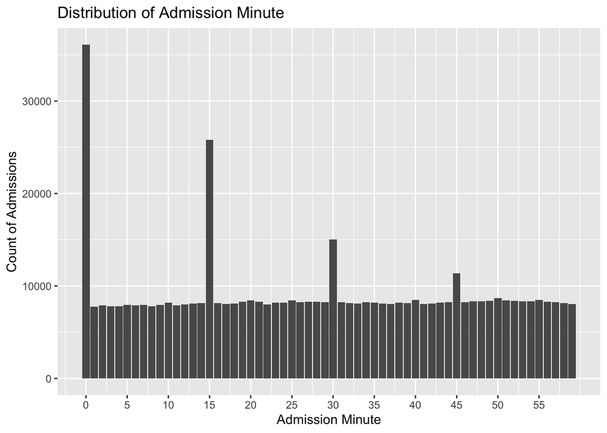

```r
admissions_tble |>
  mutate(admission_minute = minute(admittime)) |>
  count(admission_minute) |>
  print(width = Inf) |>
  ggplot(aes(x = admission_minute, y = n)) +
  geom_col(binwidth = 1) +
  labs(title = "Distribution of Admission Minute",
       x = "Admission Minute",
       y = "Count of Admissions") +
  scale_x_continuous(breaks = seq(0, 59, by = 5))
```

The distribution of admission minute is relatively uniform, with spikes at 0, 15, 30, and 45 minutes, in decreasing magnitude. This may be due to the fact that many admissions are scheduled on the hour or at quarter-hour intervals, leading to a higher number of admissions at these times. Surgeries and other events that can be scheduled may occur at these quarter-hour or hour intervals, which leads to increased admissions at these times.

The graph of length of hospital stay.

```
# A tibble: 546,028 × 17
   subject_id  hadm_id admittime           dischtime           deathtime
        <int>    <int> <dttm>              <dttm>              <dttm>
 1   10000032 22595853 2180-05-06 22:23:00 2180-05-07 17:15:00 NA
 2   10000032 22841357 2180-06-26 18:27:00 2180-06-27 18:49:00 NA
 3   10000032 25742920 2180-08-05 23:44:00 2180-08-07 17:50:00 NA
 4   10000032 29079034 2180-07-23 12:35:00 2180-07-25 17:55:00 NA
 5   10000068 25022803 2160-03-03 23:16:00 2160-03-04 06:26:00 NA
 6   10000084 23052089 2160-11-21 01:56:00 2160-11-25 14:52:00 NA
 7   10000084 29888819 2160-12-28 05:11:00 2160-12-28 16:07:00 NA
 8   10000108 27250926 2163-09-27 23:17:00 2163-09-28 09:04:00 NA
 9   10000117 22927623 2181-11-15 02:05:00 2181-11-15 14:52:00 NA
10   10000117 27988844 2183-09-18 18:10:00 2183-09-21 16:30:00 NA
   admission_type    admit_provider_id admission_location     discharge_location
   <chr>             <chr>             <chr>                  <chr>
```

[output cut: 35 more lines]

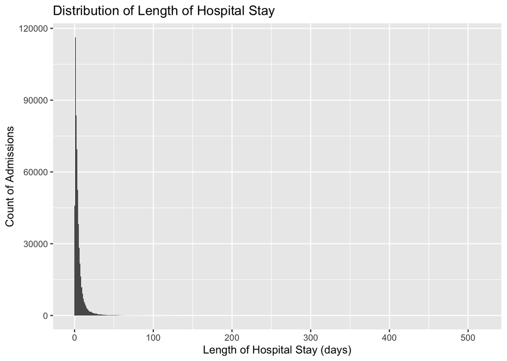

```r
admissions_tble |>
  mutate(los_days = as.numeric(
    difftime(dischtime, admittime, units = "days"))
    ) |>
  print(width = Inf) |>
  ggplot(aes(x = los_days)) +
  geom_histogram(binwidth = 1) +
  labs(title = "Distribution of Length of Hospital Stay",
       x = "Length of Hospital Stay (days)",
       y = "Count of Admissions")
```

Majority of admissions have stays of less than 50 days, with a long tail of admissions with longer stays. The distribution is right-skewed, indicating that most patients have relatively short hospital stays, while a smaller number of patients have much longer stays. The long tail may be due to the fact that some patients have complex medical conditions or complications that require extended hospitalization. It is normal for patients to have shorter stays since once patients are diagnosed and stable, the system pushes to discharge.

## Q4. `patients` data

Patient information is available in `patients.csv.gz`. See https://mimic.mit.edu/docs/iv/modules/hosp/patients/ for details of each field in this file. The first 10 lines are

```bash
zcat < ~/mimic/hosp/patients.csv.gz | head
```

```
subject_id,gender,anchor_age,anchor_year,anchor_year_group,dod
10000032,F,52,2180,2014 - 2016,2180-09-09
10000048,F,23,2126,2008 - 2010,
10000058,F,33,2168,2020 - 2022,
10000068,F,19,2160,2008 - 2010,
10000084,M,72,2160,2017 - 2019,2161-02-13
10000102,F,27,2136,2008 - 2010,
10000108,M,25,2163,2014 - 2016,
10000115,M,24,2154,2017 - 2019,
10000117,F,48,2174,2008 - 2010,
```

### Q4.1 Ingestion

Import `patients.csv.gz` (https://mimic.mit.edu/docs/iv/modules/hosp/patients/) as a tibble `patients_tble`.

**Solution:**

```r
patients_tble <-
  fread("~/mimic/hosp/patients.csv.gz") |>
  as_tibble() |>
  print(n=10, wide=Inf)
```

```
# A tibble: 364,627 × 6
   subject_id gender anchor_age anchor_year anchor_year_group dod
        <int> <chr>       <int>       <int> <chr>             <IDate>
 1   10000032 F              52        2180 2014 - 2016       2180-09-09
 2   10000048 F              23        2126 2008 - 2010       NA
 3   10000058 F              33        2168 2020 - 2022       NA
 4   10000068 F              19        2160 2008 - 2010       NA
 5   10000084 M              72        2160 2017 - 2019       2161-02-13
 6   10000102 F              27        2136 2008 - 2010       NA
 7   10000108 M              25        2163 2014 - 2016       NA
 8   10000115 M              24        2154 2017 - 2019       NA
 9   10000117 F              48        2174 2008 - 2010       NA
10   10000161 M              60        2163 2020 - 2022       NA
# ℹ 364,617 more rows
```

### Q4.2 Summary and visualization

Summarize variables `gender` and `anchor_age` by graphics, and explain any patterns you see.

**Solution:** Summarizing gender:

```
# A tibble: 2 × 2
  gender      n
  <chr>   <int>
1 F      191984
2 M      172643
```

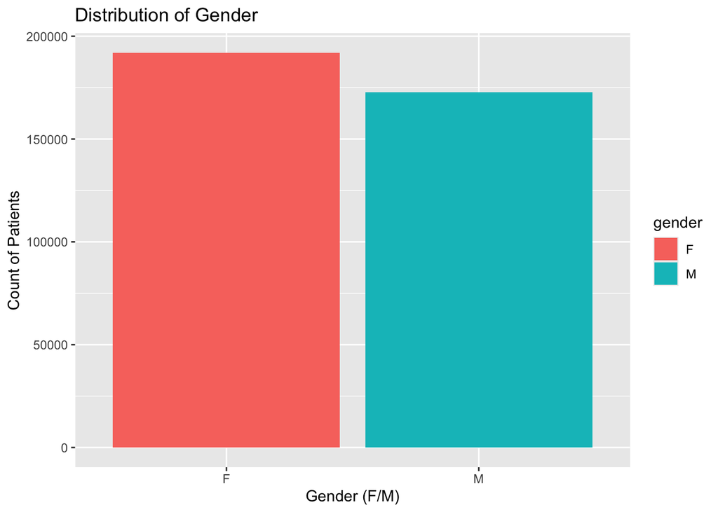

```r
patients_tble |>
  count(gender) |>
  print(width = Inf) |>
  ggplot(aes(x = gender, y = n, fill = gender)) +
  geom_col() +
  labs(title = "Distribution of Gender",
       x = "Gender (F/M)",
       y = "Count of Patients")
```

There are more females than males in the MIMIC-IV dataset. This may be due to the fact that females tend to have longer life expectancy than males, and therefore may be more likely to be admitted to the hospital and require ICU care. Additionally, certain medical conditions that are more prevalent in females, such as autoimmune diseases and certain types of cancer, may also contribute to the higher number of female patients in the dataset.

Summarizing anchor age:

```
# A tibble: 73 × 2
   anchor_age     n
        <int> <int>
 1         18  4682
 2         19  7848
 3         20 11031
 4         21  9579
 5         22  9051
 6         23  8553
 7         24  7956
 8         25  7323
 9         26  6818
10         27  6610
# ℹ 63 more rows
```

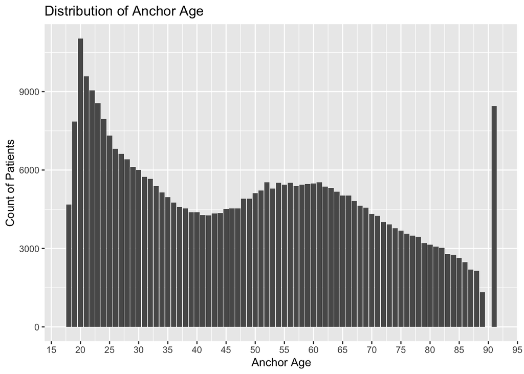

```r
patients_tble |>
  count(anchor_age) |>
  print(width = Inf) |>
  ggplot(aes(x = anchor_age, y = n)) +
  geom_col() +
  labs(title = "Distribution of Anchor Age",
       x = "Anchor Age",
       y = "Count of Patients") +
  scale_x_continuous(breaks = seq(0, 100, by = 5))
```

## Q5. Lab results

`labevents.csv.gz` (https://mimic.mit.edu/docs/iv/modules/hosp/labevents/) contains all laboratory measurements for patients. The first 10 lines are

```bash
zcat < ~/mimic/hosp/labevents.csv.gz | head
```

```
labevent_id,subject_id,hadm_id,specimen_id,itemid,order_provider_id,charttime,storetime,value,valuenum,valueuom,ref_range_lower,ref_range_upper,flag,priority,comments
1,10000032,,2704548,50931,P69FQC,2180-03-23 11:51:00,2180-03-23 15:56:00,___,95,mg/dL,70,100,,ROUTINE,"IF FASTING, 70-100 NORMAL, >125 PROVISIONAL DIABETES."
2,10000032,,36092842,51071,P69FQC,2180-03-23 11:51:00,2180-03-23 16:00:00,NEG,,,,,,ROUTINE,
3,10000032,,36092842,51074,P69FQC,2180-03-23 11:51:00,2180-03-23 16:00:00,NEG,,,,,,ROUTINE,
4,10000032,,36092842,51075,P69FQC,2180-03-23 11:51:00,2180-03-23 16:00:00,NEG,,,,,,ROUTINE,"BENZODIAZEPINE IMMUNOASSAY SCREEN DOES NOT DETECT SOME DRUGS,;INCLUDING LORAZEPAM, CLONAZEPAM, AND FLUNITRAZEPAM."
5,10000032,,36092842,51079,P69FQC,2180-03-23 11:51:00,2180-03-23 16:00:00,NEG,,,,,,ROUTINE,
6,10000032,,36092842,51087,P69FQC,2180-03-23 11:51:00,,,,,,,,ROUTINE,RANDOM.
7,10000032,,36092842,51089,P69FQC,2180-03-23 11:51:00,2180-03-23 16:15:00,,,,,,,ROUTINE,PRESUMPTIVELY POSITIVE.
8,10000032,,36092842,51090,P69FQC,2180-03-23 11:51:00,2180-03-23 16:00:00,NEG,,,,,,ROUTINE,METHADONE ASSAY DETECTS ONLY METHADONE (NOT OTHER OPIATES/OPIOIDS).
9,10000032,,36092842,51092,P69FQC,2180-03-23 11:51:00,2180-03-23 16:00:00,NEG,,,,,,ROUTINE,"OPIATE IMMUNOASSAY SCREEN DOES NOT DETECT SYNTHETIC OPIOIDS;SUCH AS METHADONE, OXYCODONE, FENTANYL, BUPRENORPHINE, TRAMADOL,;NALOXONE, MEPERIDINE.  SEE ONLINE LAB MANUAL FOR DETAILS."
```

`d_labitems.csv.gz` (https://mimic.mit.edu/docs/iv/modules/hosp/d_labitems/) is the dictionary of lab measurements.

```bash
zcat < ~/mimic/hosp/d_labitems.csv.gz | head
```

```
itemid,label,fluid,category
50801,Alveolar-arterial Gradient,Blood,Blood Gas
50802,Base Excess,Blood,Blood Gas
50803,"Calculated Bicarbonate, Whole Blood",Blood,Blood Gas
50804,Calculated Total CO2,Blood,Blood Gas
50805,Carboxyhemoglobin,Blood,Blood Gas
50806,"Chloride, Whole Blood",Blood,Blood Gas
50808,Free Calcium,Blood,Blood Gas
50809,Glucose,Blood,Blood Gas
50810,"Hematocrit, Calculated",Blood,Blood Gas
```

We are interested in the lab measurements of albumin (50862), creatinine (50912), potassium (50971), sodium (50983), chloride (50902), bicarbonate (50882), hematocrit (51221), white blood cell count (51301), and glucose (50931). Retrieve a subset of `labevents.csv.gz` that only containing these items for the patients in `icustays_tble`. Further restrict to the last available measurement (by `storetime`) before the ICU stay. The final `labevents_tble` should have one row per ICU stay and columns for each lab measurement.

[figure not shown]

Hint: Use the Parquet format you generated in Homework 2. For reproducibility, make `labevents_pq` folder available at the current working directory `hw3`, for example, by a symbolic link.

```r
labevents_tble <-
  open_dataset("labevents_pq", format = "parquet") |>
  to_duckdb() |>
  select(subject_id, itemid, charttime,
         storetime, valuenum) |>
  filter(
    itemid %in% c(50862, 50912, 50971,
                  50983, 50902, 50882,
                  51221, 51301, 50931)
    ) |>
  left_join(
    select(icustays_tble, subject_id, stay_id, intime),
    by = "subject_id",
    copy = TRUE
  ) |>
  filter(!is.na(intime), storetime < intime) |>
  group_by(subject_id, stay_id, itemid) |>
  slice_max(storetime, n = 1, with_ties = FALSE) |>
  ungroup() |>
  mutate(lab = case_when(
    itemid == 50862 ~ "albumin",
    itemid == 50912 ~ "creatinine",
    itemid == 50971 ~ "potassium",
    itemid == 50983 ~ "sodium",
    itemid == 50902 ~ "chloride",
    itemid == 50882 ~ "bicarbonate",
    itemid == 51221 ~ "hematocrit",
    itemid == 51301 ~ "white_blood_cell_count",
    itemid == 50931 ~ "glucose"
  )) |>
  select(subject_id, stay_id, lab, valuenum) |>
  collect() |>
  pivot_wider(names_from = lab, values_from = valuenum) %>%
  relocate(sort(names(.)[-(1:2)]), .after = 2) %>%
  arrange(subject_id, stay_id) %>%
  print(width = Inf)
```

```
# A tibble: 88,098 × 11
   subject_id  stay_id albumin bicarbonate chloride creatinine glucose
        <dbl>    <int>   <dbl>       <dbl>    <dbl>      <dbl>   <dbl>
 1   10000032 39553978     3.6          25       95        0.7     102
 2   10000690 37081114     3.4          26      100        1        85
 3   10000980 39765666     4.7          21      109        2.3      89
 4   10001217 34592300     4.7          30      104        0.5      87
 5   10001217 37067082     4.7          22      108        0.6     112
 6   10001725 31205490    NA            NA       98       NA        NA
 7   10001843 39698942     2.4          28       97        1.3     131
 8   10001884 37510196     4.4          30       88        1.1     141
 9   10002013 39060235     3.6          24      102        0.9     288
10   10002114 34672098     3.2          18       NA        3.1      95
   hematocrit potassium sodium white_blood_cell_count
        <dbl>     <dbl>  <dbl>                  <dbl>
 1       41.1       6.7    126                    6.9
 2       36.1       4.8    137                    7.1
 3       27.3       3.9    144                    5.3
 4       37.4       4.1    142                    5.4
 5       38.1       4.2    142                   15.7
 6       NA         4.1    139                   NA
 7       31.4       3.9    138                   10.4
 8       39.7       4.5    130                   12.2
 9       34.9       3.5    137                    7.2
10       34.3       6.5    125                   16.8
# ℹ 88,088 more rows
```

```r
labevents_tble |>
  summarise(num_stays = n_distinct(stay_id))
```

```
# A tibble: 1 × 1
  num_stays
      <int>
1     88098
```

## Q6. Vitals from charted events

`chartevents.csv.gz` (https://mimic.mit.edu/docs/iv/modules/icu/chartevents/) contains all the charted data available for a patient. During their ICU stay, the primary repository of a patient’s information is their electronic chart. The `itemid` variable indicates a single measurement type in the database. The `value` variable is the value measured for `itemid`. The first 10 lines of `chartevents.csv.gz` are

```bash
zcat < ~/mimic/icu/chartevents.csv.gz | head
```

```
subject_id,hadm_id,stay_id,caregiver_id,charttime,storetime,itemid,value,valuenum,valueuom,warning
10000032,29079034,39553978,18704,2180-07-23 12:36:00,2180-07-23 14:45:00,226512,39.4,39.4,kg,0
10000032,29079034,39553978,18704,2180-07-23 12:36:00,2180-07-23 14:45:00,226707,60,60,Inch,0
10000032,29079034,39553978,18704,2180-07-23 12:36:00,2180-07-23 14:45:00,226730,152,152,cm,0
10000032,29079034,39553978,18704,2180-07-23 14:00:00,2180-07-23 14:18:00,220048,SR (Sinus Rhythm),,,0
10000032,29079034,39553978,18704,2180-07-23 14:00:00,2180-07-23 14:18:00,224642,Oral,,,0
10000032,29079034,39553978,18704,2180-07-23 14:00:00,2180-07-23 14:18:00,224650,None,,,0
10000032,29079034,39553978,18704,2180-07-23 14:00:00,2180-07-23 14:20:00,223761,98.7,98.7,°F,0
10000032,29079034,39553978,18704,2180-07-23 14:11:00,2180-07-23 14:17:00,220179,84,84,mmHg,0
10000032,29079034,39553978,18704,2180-07-23 14:11:00,2180-07-23 14:17:00,220180,48,48,mmHg,0
```

`d_items.csv.gz` (https://mimic.mit.edu/docs/iv/modules/icu/d_items/) is the dictionary for the `itemid` in `chartevents.csv.gz`.

```bash
zcat < ~/mimic/icu/d_items.csv.gz | head
```

```
itemid,label,abbreviation,linksto,category,unitname,param_type,lownormalvalue,highnormalvalue
220001,Problem List,Problem List,chartevents,General,,Text,,
220003,ICU Admission date,ICU Admission date,datetimeevents,ADT,,Date and time,,
220045,Heart Rate,HR,chartevents,Routine Vital Signs,bpm,Numeric,,
220046,Heart rate Alarm - High,HR Alarm - High,chartevents,Alarms,bpm,Numeric,,
220047,Heart Rate Alarm - Low,HR Alarm - Low,chartevents,Alarms,bpm,Numeric,,
220048,Heart Rhythm,Heart Rhythm,chartevents,Routine Vital Signs,,Text,,
220050,Arterial Blood Pressure systolic,ABPs,chartevents,Routine Vital Signs,mmHg,Numeric,90,140
220051,Arterial Blood Pressure diastolic,ABPd,chartevents,Routine Vital Signs,mmHg,Numeric,60,90
220052,Arterial Blood Pressure mean,ABPm,chartevents,Routine Vital Signs,mmHg,Numeric,,
```

We are interested in the vitals for ICU patients: heart rate (220045), systolic non-invasive blood pressure (220179), diastolic non-invasive blood pressure (220180), body temperature in Fahrenheit (223761), and respiratory rate (220210). Retrieve a subset of `chartevents.csv.gz` only containing these items for the patients in `icustays_tble`. Further restrict to the first vital measurement (by `storetime`) within the ICU stay. The final `chartevents_tble` should have one row per ICU stay and columns for each vital measurement.

[figure not shown]

Hint: Use the Parquet format you generated in Homework 2. For reproducibility, make `chartevents_pq` folder available at the current working directory, for example, by a symbolic link.

```r
d_items <-
  fread("~/mimic/icu/d_items.csv.gz") |>
  as_tibble() |>
  print(width=Inf)
```

```
# A tibble: 4,095 × 9
   itemid label                               abbreviation       linksto
    <int> <chr>                               <chr>              <chr>
 1 220001 Problem List                        Problem List       chartevents
 2 220003 ICU Admission date                  ICU Admission date datetimeevents
 3 220045 Heart Rate                          HR                 chartevents
 4 220046 Heart rate Alarm - High             HR Alarm - High    chartevents
 5 220047 Heart Rate Alarm - Low              HR Alarm - Low     chartevents
 6 220048 Heart Rhythm                        Heart Rhythm       chartevents
 7 220050 Arterial Blood Pressure systolic    ABPs               chartevents
 8 220051 Arterial Blood Pressure diastolic   ABPd               chartevents
 9 220052 Arterial Blood Pressure mean        ABPm               chartevents
10 220056 Arterial Blood Pressure Alarm - Low ABP Alarm - Low    chartevents
   category            unitname param_type    lownormalvalue highnormalvalue
   <chr>               <chr>    <chr>                  <int>           <dbl>
 1 General             ""       Text                      NA              NA
 2 ADT                 ""       Date and time             NA              NA
 3 Routine Vital Signs "bpm"    Numeric                   NA              NA
 4 Alarms              "bpm"    Numeric                   NA              NA
 5 Alarms              "bpm"    Numeric                   NA              NA
 6 Routine Vital Signs ""       Text                      NA              NA
 7 Routine Vital Signs "mmHg"   Numeric                   90             140
 8 Routine Vital Signs "mmHg"   Numeric                   60              90
 9 Routine Vital Signs "mmHg"   Numeric                   NA              NA
10 Alarms              "mmHg"   Numeric                   NA              NA
# ℹ 4,085 more rows
```

Let’s pick the items I want to look at specifically.

```r
chartitem_itemid <- d_items |>
  filter(itemid %in% c(
    220045,
    220179,
    220180,
    223761,
    220210
    )) |>
  print(width=Inf)
```

```
# A tibble: 5 × 9
  itemid label                                 abbreviation  linksto
   <int> <chr>                                 <chr>         <chr>
1 220045 Heart Rate                            HR            chartevents
2 220179 Non Invasive Blood Pressure systolic  NBPs          chartevents
3 220180 Non Invasive Blood Pressure diastolic NBPd          chartevents
4 220210 Respiratory Rate                      RR            chartevents
5 223761 Temperature Fahrenheit                Temperature F chartevents
  category            unitname param_type lownormalvalue highnormalvalue
  <chr>               <chr>    <chr>               <int>           <dbl>
1 Routine Vital Signs bpm      Numeric                NA              NA
2 Routine Vital Signs mmHg     Numeric                NA              NA
3 Routine Vital Signs mmHg     Numeric                NA              NA
4 Respiratory         insp/min Numeric                NA              NA
5 Routine Vital Signs °F       Numeric                NA              NA
```

```r
clean_names <- chartitem_itemid$label |>
  str_to_lower() |>
  str_replace_all(" ", "_") |>
  str_replace_all("[^a-z0-9_]", "")

name_map <- setNames(as.character(chartitem_itemid$itemid), clean_names)
```

```r
chartevents_tble <- open_dataset("chartevents_pq", format = "parquet") |>
  filter(
    itemid %in% chartitem_itemid$itemid
    ) |>
  to_duckdb() |>
  select(subject_id, stay_id, itemid,
         charttime, storetime, valuenum) |>
  left_join(
    select(icustays_tble, stay_id, intime, outtime),
    by = c("stay_id"),
    copy = TRUE
  ) |>
  filter(storetime >= intime, storetime <= outtime) |>
  group_by(subject_id, stay_id, itemid) |>
  slice_min(storetime, n = 1, with_ties = TRUE) |>
  summarise(
    valuenum = mean(valuenum, na.rm = TRUE),
    .groups = "drop"
    ) |>
  pivot_wider(names_from = itemid, values_from = valuenum) |>
  rename(!!!name_map) |>
  collect() |>
  arrange(subject_id, stay_id) %>%
  relocate(sort(names(.)[-(1:2)]), .after = 2) %>%
  print(width = Inf)
```

```
# A tibble: 94,363 × 7
   subject_id  stay_id heart_rate non_invasive_blood_pressure_diastolic
        <dbl>    <dbl>      <dbl>                                 <dbl>
 1   10000032 39553978       91                                    48
 2   10000690 37081114       78                                    56.5
 3   10000980 39765666       76                                   102
 4   10001217 34592300       79.3                                  93.3
 5   10001217 37067082       86                                    90
 6   10001725 31205490       86                                    56
 7   10001843 39698942      124.                                   78
 8   10001884 37510196       49                                    30.5
 9   10002013 39060235       80                                    62
10   10002114 34672098      110.                                   80
   non_invasive_blood_pressure_systolic respiratory_rate temperature_fahrenheit
                                  <dbl>            <dbl>                  <dbl>
 1                                 84               24                     98.7
 2                                106               24.3                   97.7
 3                                154               23.5                   98
 4                                156               14                     97.6
 5                                151               18                     98.5
 6                                 73               19                     97.7
 7                                110               16.5                   97.9
 8                                174.              13                     98.1
 9                                 98.5             14                     97.2
10                                112               21                     97.9
# ℹ 94,353 more rows
```

## Q7. Putting things together

Let us create a tibble `mimic_icu_cohort` for all ICU stays, where rows are all ICU stays of adults (age at `intime` >= 18) and columns contain at least following variables

- all variables in `icustays_tble`
- all variables in `admissions_tble`
- all variables in `patients_tble`
- the last lab measurements before the ICU stay in `labevents_tble`
- the first vital measurements during the ICU stay in `chartevents_tble`

The final `mimic_icu_cohort` should have one row per ICU stay and columns for each variable.

[figure not shown]

```r
mimic_icu_cohort <- icustays_tble |>
  left_join(
    admissions_tble,
    by = c("subject_id", "hadm_id")
    ) |>
  left_join(
    patients_tble,
    by = "subject_id"
    ) |>
  left_join(
    labevents_tble,
    by = c("subject_id", "stay_id")
    ) |>
  left_join(
    chartevents_tble,
    by = c("subject_id", "stay_id")
    ) |>
  filter(anchor_age >= 18) |>
  print(width = Inf)
```

```
# A tibble: 94,458 × 41
   subject_id  hadm_id  stay_id first_careunit
        <dbl>    <int>    <dbl> <chr>
 1   10000032 29079034 39553978 Medical Intensive Care Unit (MICU)
 2   10000690 25860671 37081114 Medical Intensive Care Unit (MICU)
 3   10000980 26913865 39765666 Medical Intensive Care Unit (MICU)
 4   10001217 24597018 37067082 Surgical Intensive Care Unit (SICU)
 5   10001217 27703517 34592300 Surgical Intensive Care Unit (SICU)
 6   10001725 25563031 31205490 Medical/Surgical Intensive Care Unit (MICU/SICU)
 7   10001843 26133978 39698942 Medical/Surgical Intensive Care Unit (MICU/SICU)
 8   10001884 26184834 37510196 Medical Intensive Care Unit (MICU)
 9   10002013 23581541 39060235 Cardiac Vascular Intensive Care Unit (CVICU)
10   10002114 27793700 34672098 Coronary Care Unit (CCU)
   last_careunit                                    intime
   <chr>                                            <dttm>
```

[output cut: 119 more lines]

## Q8. Exploratory data analysis (EDA)

Summarize the following information about the ICU stay cohort `mimic_icu_cohort` using appropriate numerics or graphs:

- Length of ICU stay `los` vs demographic variables (race, insurance, marital_status, gender, age at intime)

```r
mimic_icu_cohort |>
  mutate(
    age_intime = anchor_age + year(intime) - anchor_year
    ) |>
  select(
    los, race, insurance, marital_status,
    gender, age_intime
    ) |>
  tbl_summary(
    by = gender,
    statistic = list(
      los ~ "{median} ({p25}, {p75})",
      age_intime ~ "{median} ({p25}, {p75})"
    ),
    label = list(
      los ~ "ICU Length of Stay (days)",
      age_intime ~ "Age at ICU admission"
    )
  ) |>
    add_p() |>
    bold_labels()
```

[output not shown]

| **Characteristic** | **F** N = 41,583<sup>1</sup> | **M** N = 52,875<sup>1</sup> | **p-value**<sup>2</sup> |
| --- | --- | --- | --- |
| ICU Length of Stay (days) | 1.9 (1.1, 3.8) | 2.0 (1.1, 3.9) | <0.001 |
| Unknown | 6 | 8 |  |
| race |  |  | <0.001 |
| AMERICAN INDIAN/ALASKA NATIVE | 93 (0.2%) | 105 (0.2%) |  |
| ASIAN | 493 (1.2%) | 602 (1.1%) |  |
| ASIAN - ASIAN INDIAN | 81 (0.2%) | 167 (0.3%) |  |
| ASIAN - CHINESE | 508 (1.2%) | 554 (1.0%) |  |
| ASIAN - KOREAN | 32 (<0.1%) | 41 (<0.1%) |  |
| ASIAN - SOUTH EAST ASIAN | 153 (0.4%) | 255 (0.5%) |  |
| BLACK/AFRICAN | 189 (0.5%) | 242 (0.5%) |  |
| BLACK/AFRICAN AMERICAN | 4,789 (12%) | 3,888 (7.4%) |  |
| BLACK/CAPE VERDEAN | 297 (0.7%) | 359 (0.7%) |  |
| BLACK/CARIBBEAN ISLAND | 335 (0.8%) | 286 (0.5%) |  |
| HISPANIC OR LATINO | 300 (0.7%) | 483 (0.9%) |  |
| HISPANIC/LATINO - CENTRAL AMERICAN | 23 (<0.1%) | 50 (<0.1%) |  |
| HISPANIC/LATINO - COLUMBIAN | 57 (0.1%) | 45 (<0.1%) |  |
| HISPANIC/LATINO - CUBAN | 46 (0.1%) | 54 (0.1%) |  |
| HISPANIC/LATINO - DOMINICAN | 336 (0.8%) | 410 (0.8%) |  |
| HISPANIC/LATINO - GUATEMALAN | 93 (0.2%) | 134 (0.3%) |  |
| HISPANIC/LATINO - HONDURAN | 31 (<0.1%) | 57 (0.1%) |  |
| HISPANIC/LATINO - MEXICAN | 36 (<0.1%) | 52 (<0.1%) |  |
| HISPANIC/LATINO - PUERTO RICAN | 511 (1.2%) | 703 (1.3%) |  |
| HISPANIC/LATINO - SALVADORAN | 74 (0.2%) | 100 (0.2%) |  |
| MULTIPLE RACE/ETHNICITY | 30 (<0.1%) | 44 (<0.1%) |  |
| NATIVE HAWAIIAN OR OTHER PACIFIC ISLANDER | 48 (0.1%) | 85 (0.2%) |  |
| OTHER | 1,343 (3.2%) | 1,791 (3.4%) |  |
| PATIENT DECLINED TO ANSWER | 197 (0.5%) | 318 (0.6%) |  |
| PORTUGUESE | 156 (0.4%) | 269 (0.5%) |  |
| SOUTH AMERICAN | 47 (0.1%) | 57 (0.1%) |  |
| UNABLE TO OBTAIN | 742 (1.8%) | 1,139 (2.2%) |  |
| UNKNOWN | 3,338 (8.0%) | 5,119 (9.7%) |  |
| WHITE | 25,529 (61%) | 33,359 (63%) |  |
| WHITE - BRAZILIAN | 104 (0.3%) | 117 (0.2%) |  |
| WHITE - EASTERN EUROPEAN | 113 (0.3%) | 159 (0.3%) |  |
| WHITE - OTHER EUROPEAN | 969 (2.3%) | 1,341 (2.5%) |  |
| WHITE - RUSSIAN | 490 (1.2%) | 490 (0.9%) |  |
| insurance |  |  |  |
|  | 451 (1.1%) | 1,072 (2.0%) |  |
| Medicaid | 6,585 (16%) | 7,655 (14%) |  |
| Medicare | 24,163 (58%) | 27,656 (52%) |  |
| No charge | 3 (<0.1%) | 5 (<0.1%) |  |
| Other | 723 (1.7%) | 1,605 (3.0%) |  |
| Private | 9,658 (23%) | 14,882 (28%) |  |
| marital_status |  |  | <0.001 |
|  | 3,104 (7.5%) | 4,657 (8.8%) |  |
| DIVORCED | 3,624 (8.7%) | 3,308 (6.3%) |  |
| MARRIED | 14,632 (35%) | 27,275 (52%) |  |
| SINGLE | 12,127 (29%) | 14,658 (28%) |  |
| WIDOWED | 8,096 (19%) | 2,977 (5.6%) |  |
| Age at ICU admission | 68 (55, 79) | 65 (55, 76) | <0.001 |

<sup>1</sup> Median (Q1, Q3); n (%)  
<sup>2</sup> Wilcoxon rank sum test; Pearson’s Chi-squared test; NA

- Length of ICU stay `los` vs the last available lab measurements before ICU stay

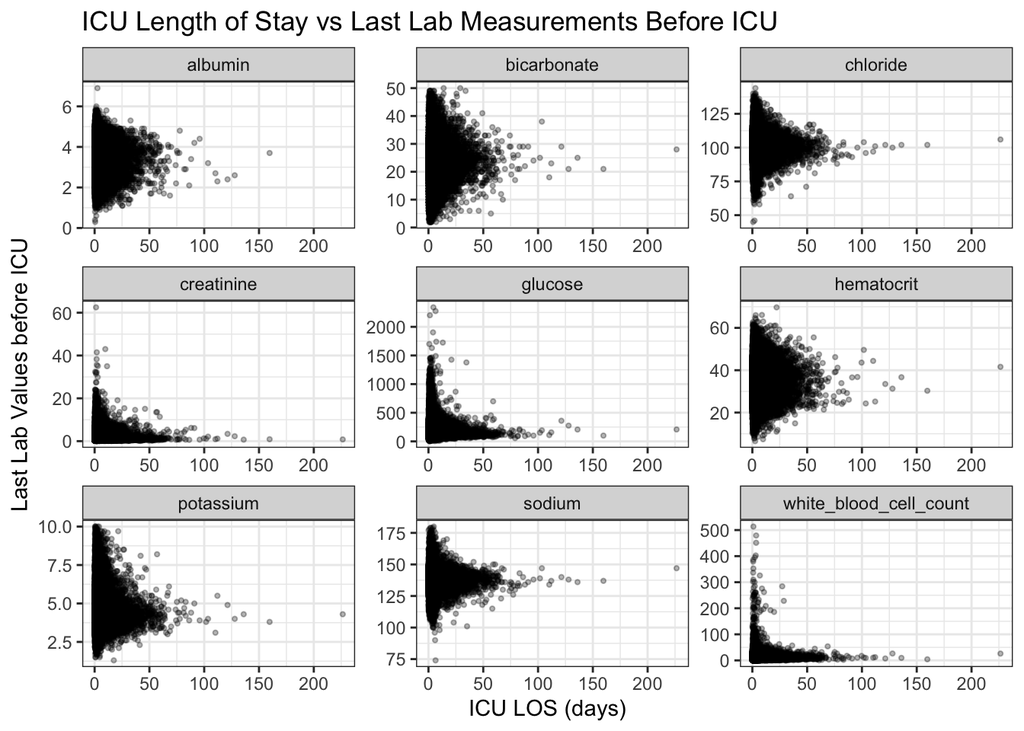

```r
labs = c("albumin", "creatinine", "potassium",
         "sodium", "chloride", "bicarbonate",
         "hematocrit", "white_blood_cell_count", "glucose")

mimic_icu_cohort %>%
  select(los, all_of(labs)) %>%
  pivot_longer(
    -los,
    names_to = "lab",
    values_to = "value"
    ) %>%
  ggplot(aes(x = los, y = value)) +
  geom_point(alpha = 0.3, size = 0.8) +
  facet_wrap(~ lab, scales = "free") +
  labs(
    title = "ICU Length of Stay vs Last Lab Measurements Before ICU",
    x = "ICU LOS (days)",
    y = "Last Lab Values before ICU"
  ) +
  theme_bw()
```

- Length of ICU stay `los` vs the first vital measurements within the ICU stay

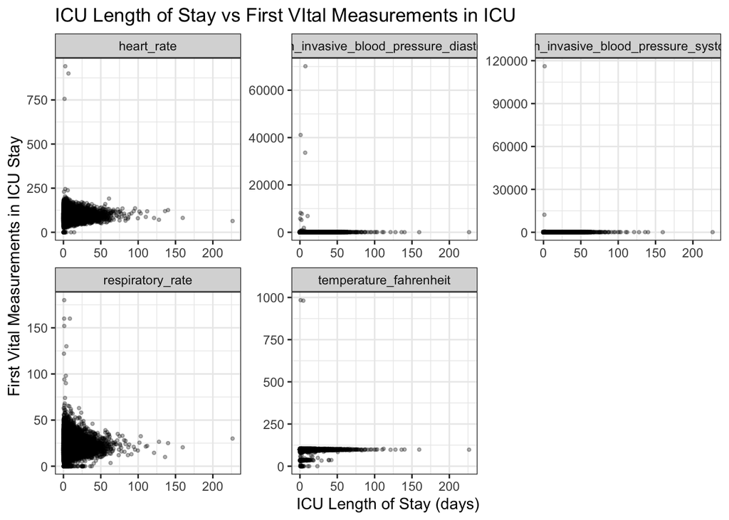

```r
mimic_icu_cohort %>%
  select(los, all_of(names(name_map))) %>%
  pivot_longer(-los, names_to = "lab",
               values_to = "value") %>%
  ggplot(aes(x = los, y = value)) +
  geom_point(alpha = 0.3, size = 0.8) +
  facet_wrap(~ lab, scales = "free") +
  labs(
    title = "ICU Length of Stay vs First VItal Measurements in ICU",
    x = "ICU Length of Stay (days)",
    y = "First Vital Measurements in ICU Stay"
  ) +
  theme_bw()
```

- Length of ICU stay `los` vs first ICU unit

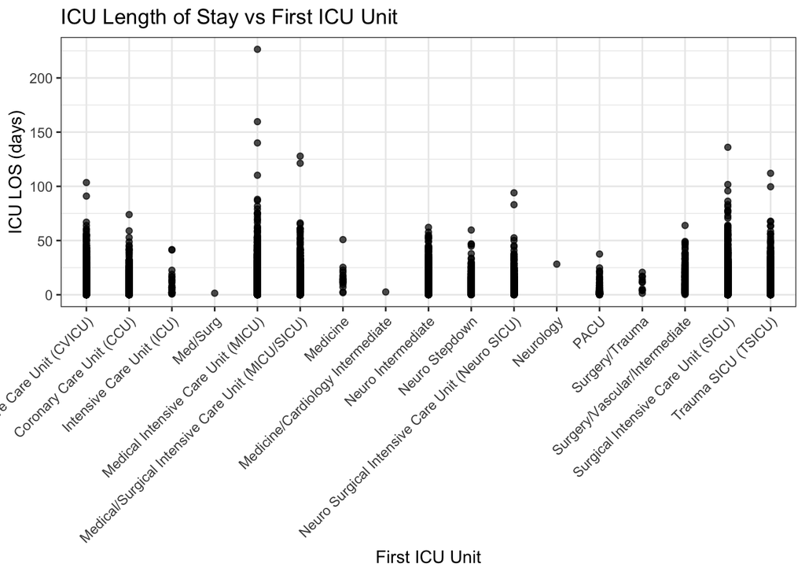

```r
ggplot(mimic_icu_cohort, aes(x = first_careunit, y = los)) +
  geom_point(alpha = 0.7) +
  labs(
    title = "ICU Length of Stay vs First ICU Unit",
    x = "First ICU Unit",
    y = "ICU LOS (days)"
  ) +
  theme_bw() +
  theme(axis.text.x = element_text(angle = 45, hjust = 1))
```

## Q9. AI assistant

Which AI assistants (e.g., GitHub Copilot) do you use when working on this assignment? Which AI model (e.g., GPT-5 mini, GPT-5, Claude Sonnet 4.5) does the AI assistant use? How do you use them? Do you think they help improve your productivity?

Give 5 instances where AI model gave incorrect or misleading answers. You can use screenshots or copy-paste the Q&A.

I used GitHub Copilot and Claude, which ran the Claude Sonnet 4.6 Extended Model. I used Copilot while writing my code as it gave me suggestions on what to code next. I used Claude for debugging and asking it questions to understand pieces of code. They did help my productivity quite a bit. There were many times where I was stuck with errors until the model finally gave a suggestion that worked to solve the problem. 5 instances where the AI models gave incorrect or misleading answers:

1. Copilot suggested an incorrect filter statement while reading the patients.csv.gz.

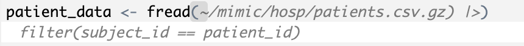

2. Copilot suggest an incorrect pile path to reading transfers.csv.gz.

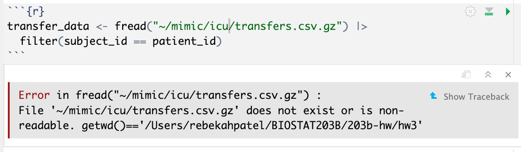

3. Copilot suggested the wrong number of patients after I found the answer earlier.

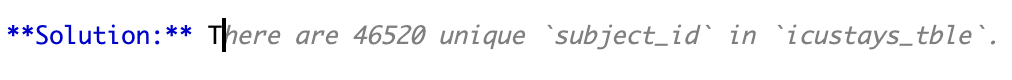

4. Copilot suggested selecting non-existent columns in a table.

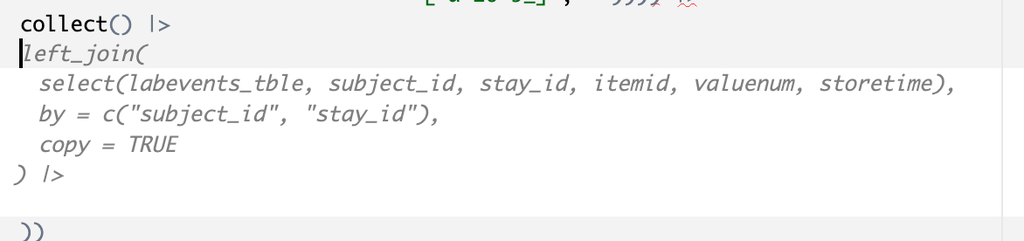

5. Claude intitally gave me incorrect code, the first three statements in the image. I had to then correct it by asking why it chose that order, and it listed to me its mistake and changed it to the correct order of the statements.

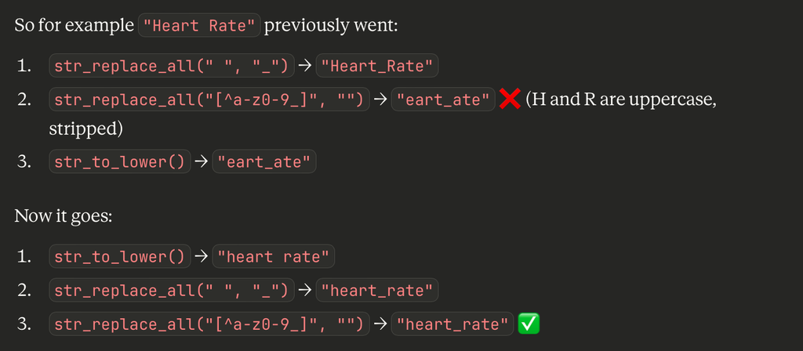